# 2020-07-06-Tensorflow - Mnist CNN

```python
from google.colab import drive
drive.mount('/content/drive')
```

[output not shown]

## **Mnist CNN**

CNN은 Pooling으로 데이터를 재 가공하는데, Window의 크기에 따라 데이터의 크기가 달라진다. 이때 크기가 줄어드는 것을 방지하기 위해서 padding을 이용한다. padding이란 원본 데이터 행렬 주변을 임의의 값으로 둘러 싸는 것이다. 대체로 의미가 없는 0으로 padding한다. Window는 filter라고도 한다.

0 | 0 | 0 | 0 | 0 0 | 1 | 2 | 1 | 1 0 | 0 | 1 | 1 | 0 ==> 4x4 0 | 0 | 2 | 3 | 2 0 | 3 | 0 | 4 | 1

위 데이터는 4x4 사진 데이터에 패딩을하여 5x5로 만든거싱고. 2x2의 window를 stride=1 을 적용하면 다시 4x4가 나오게 된다.

여러개의 window를 사용하여 만들어진 데이터 층을 convolutional layer라고 하고, 이때 여러개의 window에 의한 만들어진 레이어는 깊이가 생기고 이 깊이를 각 쉘에 배열형태로 값을 저장한다. 즉 layer가 28x28x32이면 각 쉘에 32개의 원소가 들어가게 된다. 그리고 그림을 몇개를 만들지를 결정하여 filter의 개수를 결정한다. 즉 window==filter는 4차원 배열이 되고 4번째 원소는 뽑아내려는 데이터 평면 의 개수이고 1번 2번은 행렬크기 3번은 한 쉘의 들어가는 배열의 원소의 개수가 된다.

그 이후 맥스 풀링을 해준다. max pooling이란 또 하나의 window인데, 위의 방식처럼 window를 움직이되, 모두의 합이나 평균이 아닌 그 수들중에 가장 큰 수를 뽑아내는 것이다. pooling matrix는 가중치가 없다(모두 1로 초기화된 window로 max값 뽑는다고 생각하면 된다.)

이후 다시 convolutional layer를 원하는 만큼 만드는데, 이때 window는 위처럼 각 쉘에 한개의 값을 가지는 게 아닌 위에 32개의 배열이 하나의 layer 깊이가 됐으므로 window 각 쉘에도 32개의 원소를 가지는 배열이 들어가야 한다.

pooling matrix를 몇 칸씩 건너뛰어 갈지 정하는 변수가 Stride이다.

(0,1) | (1,0) | (0,2) (2,0) | (1,2) | (0,2) (0,1) | (1,0) | (0,2)

위의 매트릭스에서 각쉘의 1번원소는 R의 농도 2번값은 G의 농도 이런식이로 생각할 수 있고, 이에 대한 윈도우도 밑에 처럼 (1,2) | (2,3) (3,4) | (4.5) 처럼 데이터와 window의 각 쉘의 배열의 원소 개수는 같아야 한다. tensor에서는 input 4차원 배열 ([None,32,32,"1"])과 filter 모양과 개수 ([5,5,"1",32]) 처럼 "1"이 같아야 한다.

tf.nn.conv2d(input,filter,stride,padding,...)함수 : convolution layer를 만드는 함수. ▶ input 4차원 배열 (예 : [None,28,28,1]) ▶ filter : W. 4차원 배열 ▶ filter의 모양과 갯수 (예 : [5,5,1,32]) • 5,5 : filter의 크기 (행X열) • 1 : 색의 갯수 (컬러의 경우는 3) • 32 : 필터의 갯수. 필터의 갯수만큼 이미지(feature map)가 만들어진다. ▶ strides=[1,Hstride,Wstride,1]. 처음과 끝은 반드시 1. 세로로 Hstride만큼 가로로 Wstride만큼 이동하며 계산. ▶ padding : 'SAME' or 'VALID' (default) 'SAME'의 경우 원래 이미지의 경계면에 0 값을 붙여서 (pad) 특성맵의 이미지 크기가 처음과 같도록 만듦.

pooling : filter를 통과한 이미지에서 작은 사이즈의 sample을 추출 (특징 극대화). tf.nn.max_pooling(input,ksize,strides,padding) ▶ input : convolution layer image ▶ ksize = [1,H,W,1] : 윈도우의 크기. 최댓값을 선택. ▶ 나머지의 의미는 위와 동일. 이후에는 특성맵의 개수를 W의 3번째 항목 개수로 지정. 최종적으로 클래스의 개수를 출력.

```python
import tensorflow as tf
import numpy as np
import matplotlib.pyplot as plt
%matplotlib inline
rng=np.random
with np.load("/content/drive/My Drive/2019 후반기 4학년 1학기/전산물리와 딥러닝/mnist.npz") as A:
    x_train=A["x_train"].reshape((-1,28,28,1)).astype(np.float32)/255. # 컬러면 마지막 1이 3이상이 될것이고, 첫번째 -1 은 알아서 개수를 지정해주는 것이다.
    y1=A["y_train"]
    x_test=A["x_test"].reshape((-1,28,28,1)).astype(np.float32)/255. # broad casting을 이용하여 /255 를 하여 정규화 해준다.
    y2=A["y_test"]
len1=y1.shape[0]
len2=y2.shape[0]
y_train=np.zeros((len1,10),dtype=np.float32) # 각 아웃풋마다 10개의 원소를 가지는 배열을 만든다. 0~9까지 들어갈 수 있기 때문이다.
y_test=np.zeros((len2,10),dtype=np.float32)
for i in range(len1):
    y_train[i,y1[i]]=1 #0으로 초기화된 배열에 class에 해당하는 원소만 1로 바꾸어준다.
for i in range(len2):
    y_test[i,y2[i]]=1
```

```python
tf.set_random_seed(100)
X = tf.placeholder(tf.float32, [None, 28,28,1]) # convolutional layer는 4차원 배열로 잡아줘야됨, 맨 처음은 데이터 개수이고, 2,3 번이 해상도이고 마지막 1 화소당 비트수이다.
                                                # 즉 RGB를 사용한다면 3을 사용할 수 있다. 이때 28 x 28 행렬에 각 쉘에는 배열이 들어가고, 화소수를 3으로 사용하면 [0,1.0,0.3]이런 식으로 들어간다.
                                                # 화소수가 1이라면 [0], [1.0], [0.6] 이런 수가 들어갈 수 있다.
Y = tf.placeholder(tf.float32, [None, 10])
W1 = tf.Variable(tf.truncated_normal([3, 3, 1, 32], stddev=0.01)) # stddev로 표준편차를 지정해준다. 이거는 empirical한 결과이다.
                                                                  # 여기서 앞의 두 수 3X3이 윈도우의 크기이고, 1은 화소수와 같아야한다. RGB를 사용한다면 3이 들어간다.
                                                                  # 그리고 마지막으로 그러한 윈도우가 32개 가 있어서, 하나의 데이터에 대해서 32개의 윈도우가 적용하여,
                                                                  # 하나의 데이터에 대해서 32개의 feature map이 나오게 된다.
                                                                  # 또한 경험적으로 W값이 너무 크거나 0 이면 안 좋다는 것을 알아내었다. 그래서 truncated_normal을 사용한다.
                                                                  # 여기서 std=0.01로 잡아줬으므로, std -0.02 ~ 0.02 사이의 값이 잡힌다.
#    Conv     -> (?, 28, 28, 32)
#    Pool     -> (?, 14, 14, 32)
L1 = tf.nn.conv2d(X, W1, strides=[1, 1, 1, 1], padding='SAME') # 위에서 선언한 윈도우(W)와 인풋을 stride를 1로하여 곱한다. stride에서 양쪽 끝 수는 1로 고정이고,
                                                               # 2번째 인자가 위아래, 3번째가 좌우로 몇칸 움직일 지 명시하는 것이다.
                                                               # 결과적으로 32개의 feature맵이 형성된다.
L1 = tf.nn.relu(L1)                                            # 그 후 Relu를 적용한다. Relu는 양수면 그 값 그대로 두고 음수면 0을 취한다.
L1 = tf.nn.max_pool(L1, ksize=[1, 2, 2, 1], strides=[1, 2, 2, 1], padding='SAME') # 2x2 풀링을 통해서 2x2행렬마다 가장 큰수를 뽑아낸다. ksize의 양쪽은 1로 고정하고, 2,3번째가 pooling matrix의 크기이다.
                                                                                  # 이때 stride는 명시한대로 아래로 2칸, 오른쪽으로 2칸이다.

W2 = tf.Variable(tf.truncated_normal([3, 3, 32, 64], stddev=0.01)) # 여기서 32는 깊이가 되므로 위에서 설정한 feature map의 개수와 같아야 한다.
#    Conv      ->(?, 14, 14, 64)
#    Pool      ->(?, 7, 7, 64)
L2 = tf.nn.conv2d(L1, W2, strides=[1, 1, 1, 1], padding='SAME')
L2 = tf.nn.relu(L2)
L2 = tf.nn.max_pool(L2, ksize=[1, 2, 2, 1],strides=[1, 2, 2, 1], padding='SAME')
L2_flat = tf.reshape(L2, [-1, 7 * 7 * 64]) # 마지막에 fully connected하기 위해 1차원 배열로 펼쳐줌
                                          #행벡터가 만들어짐 1x 7 * 7 * 64

'''
Tensor("Conv2D_1:0", shape=(?, 14, 14, 64), dtype=float32)
Tensor("Relu_1:0", shape=(?, 14, 14, 64), dtype=float32)
Tensor("MaxPool_1:0", shape=(?, 7, 7, 64), dtype=float32)
Tensor("Reshape_1:0", shape=(?, 3136), dtype=float32)
'''

# Final FC 7x7x64 inputs -> 10 outputs
W3 = tf.Variable(tf.truncated_normal([7*7*64,10],stddev=0.01))
b = tf.Variable(tf.random_normal([10]))
Yhat = tf.matmul(L2_flat, W3) + b

correct=tf.equal(tf.argmax(Yhat,1),tf.argmax(Y,1))
accuracy=tf.reduce_mean(tf.cast(correct,tf.float32))
cost = tf.reduce_mean(tf.nn.softmax_cross_entropy_with_logits_v2(logits=Yhat, labels=Y))
train=tf.train.AdamOptimizer(0.001).minimize(cost) #AdamOptimzier가 Gradient Descent Optimizer보다 좋다.
training_epochs = 10
batch_size = 100
total_batch = x_train.shape[0] // batch_size
sess=tf.Session()
sess.run(tf.global_variables_initializer())
print("Now begins: it takes some time.")
for epoch in range(training_epochs):
    for i in range(total_batch):
        batch_x = x_train[batch_size*i:batch_size*(i+1),:]
        batch_y = y_train[batch_size*i:batch_size*(i+1),:]
        sess.run(train,{X:batch_x,Y:batch_y})
    trc,tra=sess.run([cost,accuracy],{X:x_train,Y:y_train})
    print("epoch =",epoch+1)
    tec,tea=sess.run([cost,accuracy],{X:x_test,Y:y_test})
    print("train cost=",trc," train accuracy=",tra)
    print("test cost=",tec," test accuracy=",tea)
```

```
Now begins: it takes some time.
epoch = 1
train cost= 0.14721103  train accuracy= 0.95475
test cost= 0.13364607  test accuracy= 0.9596
epoch = 2
train cost= 0.08643374  train accuracy= 0.97333336
test cost= 0.0794817  test accuracy= 0.9745
epoch = 3
train cost= 0.06652573  train accuracy= 0.97915
test cost= 0.063232504  test accuracy= 0.9789
epoch = 4
train cost= 0.05087644  train accuracy= 0.98355
test cost= 0.05185403  test accuracy= 0.9813
epoch = 5
train cost= 0.040502604  train accuracy= 0.98723334
test cost= 0.04605834  test accuracy= 0.9833
epoch = 6
train cost= 0.03405491  train accuracy= 0.98905
test cost= 0.044244368  test accuracy= 0.9846
epoch = 7
train cost= 0.029578121  train accuracy= 0.99035
test cost= 0.044054393  test accuracy= 0.9858
epoch = 8
train cost= 0.026524773  train accuracy= 0.9915
test cost= 0.044613197  test accuracy= 0.9861
epoch = 9
train cost= 0.026057782  train accuracy= 0.9915
test cost= 0.047652666  test accuracy= 0.9853
epoch = 10
train cost= 0.023296997  train accuracy= 0.9925
test cost= 0.04682317  test accuracy= 0.9856
```

```
Label=[5]
Prediction=[6]
```

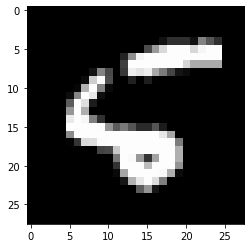

```
Label=[3]
Prediction=[8]
```

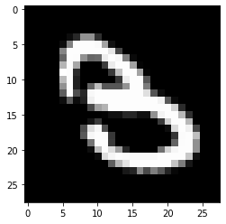

```
Label=[8]
Prediction=[2]
```

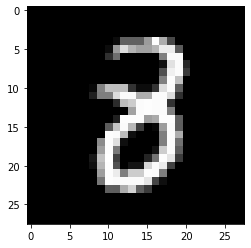

```
Label=[5]
Prediction=[3]
```

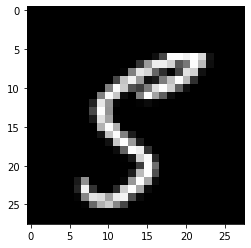

```
Label=[6]
Prediction=[0]
```

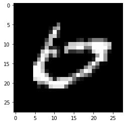

```
Label=[3]
Prediction=[5]
```

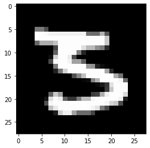

```
Label=[8]
Prediction=[2]
```

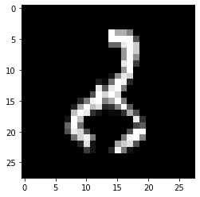

```
Label=[1]
Prediction=[8]
```

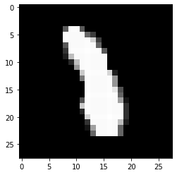

```
Label=[2]
Prediction=[1]
```

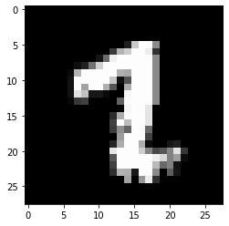

```
Label=[7]
Prediction=[2]
```

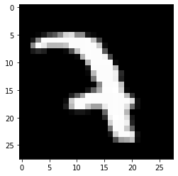

```
Label=[0]
Prediction=[6]
```

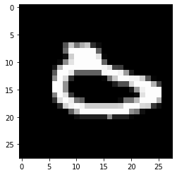

```
Label=[7]
Prediction=[5]
```

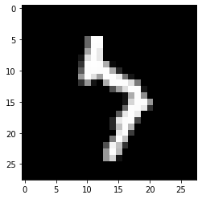

```
Label=[7]
Prediction=[9]
```

[8 more figures not shown]

```python
com=sess.run(correct,feed_dict={X:x_test,Y:y_test})
i=1
for r in range(10000):
    if com[r]==False:
        t_label=sess.run(tf.argmax(y_test[r:r+1], 1))
        t_pre=sess.run(tf.argmax(Yhat, 1), feed_dict={X: x_test[r:r + 1]})
        print("Label=[{}]\nPrediction=[{}]".format(t_label[0],t_pre[0]))
        i+=1
        plt.imshow(x_test[r:r + 1].reshape(28, 28), cmap='gray', interpolation='nearest')
        plt.show()
        if i>20:
            break
```

## **11-26**

fully connected는 모든 노드의 가중치가 들어가지만 convolutional layer는 가장 거리상으로 가까이 있는 노드의 가중치를 부여한다 <- 비정확 잘 모르겠음...

목표는 인풋 벡터에 대해서 가장 좋은 Yhat을 만드는 함수 f를 찾는것이다. 이때 함수 f의 결과 값도 벡터이다.

outlier에 의해서 overfitting이 발생한다. train cost는 감소하더라도 test cost는 증가하게 된다. 다시말해서 overfit이 발생전에는 train set과 test set의 실패율이 훈련횟수가 증가할 수록 같이 감소하지만, 어느 순간부터 train set의 실패율은 감소하지만 test set은 증가한다.

이를 방지하는 하나의 방법으로 drop-out이 있다. outlier에 대한 대비책이라고 할 수 있다.

## **drop out**

```python
# drop out 코딩
import tensorflow as tf
A=tf.constant([1,2,3,4],tf.float32)
B=tf.nn.dropout(A,rate=0.2) #여기서 rate는 각 원소를 0으로 바꿀 확률이다.
                            # 그리고 모든 원소에 대하여 1-rate로 나눈다.
                            # 그럼으로써 drop out을 하더라도 최종 합은 원래의 합과 같게 해준다.
                            # rate는 주로 0.3~0.5 를 취한다.
                            # 이렇게 함으로써 outlier가 버려질 것이라는 가정을 가지고 학습을 한다.

with tf.Session() as sess:
  print(sess.run(B))
```

```
[1.25 2.5  0.   0.  ]
```